# Lecture #11

이산형 난수 발생과 표본 선택

Junho Ahn

2022-09-08

## 난수의 발생

### sample과 sample.int 함수

**출력**  
유한 모집단에 필요한 개수의 난수를 뽑는 함수

**성질** 유한모집단이지만 복원추출(하나를 뽑고 다시 원상복귀 후 다음 뽑기)인 경우 무한 모집단과 같음

**매개변수**  
- x: 추출할 원소를 포함한 벡터를 주거나 자연수 값을 줄 수 있음. 벡터가 주어지면 주어진 벡터의 원소에서 표본을 추출하고, 자연수 값을 주면 1부터 x사이의 자연수에서 표본을 추출함  
- n: 자연수 값을 지정하며, 1부터 n사이의 자연수에서 표본을 추출함  
- size: 자연수를 지정하며 추출할 표본의 크기임  
- replace: 논리값(TRUE or FALSE)을 설정하며, TRUE면 복원추출, FALSE면 비복원 추출을 함 (Default: FALSE)  
- prob: x의 원소 또는 1에서 n사이의 값이 관찰될 확률을 설정함. 이 값이 설정되지 않으면 확률은 1/length(x) 및 1/n 으로 등확률임.

### 이산형 난수의 발생

**예제1**  
(표본설계) 어느 자치구에는 12개의 동이 있다. 조사를 위해서 이 중에서 4개의 동을 임의로 선택하는 방법

```r
x <- seq(1,12)
sample(x, size = 4)
```

```
## [1]  8  4  6 10
```

또는

```r
sample.int(12, size = 4)
```

```
## [1]  9  3  1 10
```

**예제2**  
(표본설계에 적용) 뽑힌 4개의 동에는 각각 19세 이상의 주민의 수가 12,000명, 7,000명, 5,000명 및 3,000명의 주민이 있다고 한다. 각 동에서 비례할당의 방법으로 1%의 주민을 조사대상으로 뽑으려면 어떻게 해야 하는가?

(2-1) 뽑힌 번호에 해당하는 사람을 선택하기

```r
sample.int(12000, size = 120)
```

```
##   [1]  8169  2803 10051 11239  2640  3134  4976  6453  7894   590  6074  2141
##  [13]  8115 10129  6234  8188  3959  3061  3960   560  2967  3940   291  9562
##  [25]    99  6305  6809  9150  3314  5509  3278  6275  5311 11048  4142  2586
##  [37]  9543   744 10126    26   718 11859  5383 10634  2661 10906   221  8253
##  [49]   779 11116   259  7846  7318  5921 10052 10249  9951  5851   390   975
##  [61]  9605   958 10070 10376  5984   539 11653  1918  4253  3032  2789  3544
##  [73]  9429 11907  8200 11077 11733  9253  8758  5500  6029 11727  2124  9098
##  [85]  2418   929 11204  2786  8237  5888  4720  4685  2459 10402  2152  9672
##  [97]  7998  7636  4758  3085  7245  2220  3646  6765 11417  7104  1520  8055
## [109]  5456   345  9925  9796  3272  3768  7847   351 10482 10433  5884  8585
```

```r
sample.int(7000, size = 70)
```

```
##  [1]   44 5180 1599 3254  288 1648 3979 2670 6064  623 6985  166 2986 5974 3080
## [16] 3719 4636 4236 5174 3541 1947  175 5840 4041 6208 2467 6360 6756 1433 3645
## [31] 1388 6685 5323 6763 2052  950 1946 6170 1385 1331 3500 6774 6409 5272 5056
## [46] 3434 3837 3420  335 3356 6403 1415  398 3248 6990 1682 3051  429 2571 1121
## [61] 1941 2912 2491 5833   15 3676 6706   64 2752 1057
```

```r
sample.int(5000, size = 50)
```

```
##  [1]  536  519 4836 3779 4589 2464 1547 4756 1373 1679 2729 3025 3712 4704 4393
## [16] 3554 3369 2433 4157 4528 4432 2358  901 1837 4740 4253 1366 4935 4541 3078
## [31] 1610  388 4351 2194 3464 4515 2883 4625 2591 1305 4582 4808 2500 2887 4068
## [46] 1571  621 4394 4527 2728
```

```r
sample.int(3000, size = 30)
```

```
##  [1]  756 1883 2807  466 1295 2732 2222  780  162  476 1140 1770  743 1034 1855
## [16] 1030   49 1356 2955 1744 2372 1333 1415  774 1599 1843 1389 1300 1990 2655
```

(2-2) 번호를 순서대로 나오게 하기 위해 `sort()`함수 사용하기

```r
sort(sample.int(12000, size = 120))
```

```
##   [1]    50   187   475   722   788   829   917  1110  1130  1174  1189  1278
##  [13]  1464  1511  1515  1517  1555  1577  1642  1652  1723  1739  1900  2008
##  [25]  2366  2400  2641  2836  2964  3087  3202  3402  3408  3637  3656  3817
##  [37]  3829  3937  4290  4507  4537  4564  4613  4674  4832  4958  4969  5164
##  [49]  5220  5732  5789  5791  5821  5921  5988  6105  6228  6287  6322  6326
##  [61]  6345  6583  6670  6681  6765  6770  6803  6817  6882  6923  7034  7101
##  [73]  7142  7228  7688  7749  7827  7932  8096  8171  8345  8386  8448  8559
##  [85]  8569  8590  8622  8844  9279  9290  9301  9395  9399  9668  9695  9710
##  [97]  9741  9918  9944  9983 10211 10339 10504 10531 10596 10664 10902 10992
## [109] 11017 11039 11071 11104 11160 11258 11429 11506 11567 11652 11792 11936
```

```r
sort(sample.int(7000, size = 70))
```

```
##  [1]  426  638  963 1043 1069 1085 1121 1139 1159 1389 1393 1653 1740 1966 1998
## [16] 2087 2164 2286 2330 2466 2536 2808 2871 2883 2897 2926 2969 3044 3065 3097
## [31] 3437 3476 3499 3540 3682 3702 3756 3785 3786 3819 3873 4016 4172 4176 4302
## [46] 4586 4660 4776 4824 4861 4906 4941 5069 5075 5123 5205 5282 5355 5357 5360
## [61] 5417 5485 5957 6100 6284 6294 6296 6397 6545 6976
```

```r
sort(sample.int(5000, size = 50))
```

```
##  [1]    9   19   96  153  410  543  605  658  865  951 1100 1154 1181 1434 1753
## [16] 1850 1863 1967 2036 2092 2276 2301 2392 2433 2489 2727 2765 2823 2829 2960
## [31] 3051 3345 3375 3491 3575 3607 3640 3726 3978 4019 4178 4253 4273 4521 4550
## [46] 4641 4664 4680 4733 4831
```

```r
sort(sample.int(3000, size = 30))
```

```
##  [1]   16  117  240  463  464  549  678  771  859  991 1084 1206 1245 1297 1328
## [16] 1491 1604 1813 1827 2089 2133 2202 2227 2262 2327 2457 2484 2503 2631 2955
```

**예제3**  
(등확률이 아닌 경우) 다음은 A, B, C, D가 관찰될 확률이 각각 0.1, 0.2, 0.3 및 0.4인 모집단에서 10개를 복원 추출로 뽑는 경우를 모의 실험하는 과정이다.

```r
x <- c("A", "B", "C", "D") # 모든 가능한 값을 포함한 벡터 설정
p <- c(0.1, 0.2, 0.3, 0.4) # 각 값에 대응하는 확률
sample(x, size = 10, replace = TRUE, prob = p) # 복원추출 10회
```

```
##  [1] "D" "D" "D" "D" "D" "C" "C" "B" "B" "C"
```

(복원추출) 위의 예제에서 난수 1000개를 발생시켜 도수분포표와 막대그래프를 그려본다.

```r
x <- c("A", "B", "C", "D") # 모든 가능한 값을 포함한 벡터 설정
p <- c(0.1, 0.2, 0.3, 0.4) # 각 값에 대응하는 확률
data <- sample(x, size = 1000, replace = TRUE, prob = p) # 복원추출 1000회

table(data)
```

```
## data
##   A   B   C   D
## 126 213 281 380
```

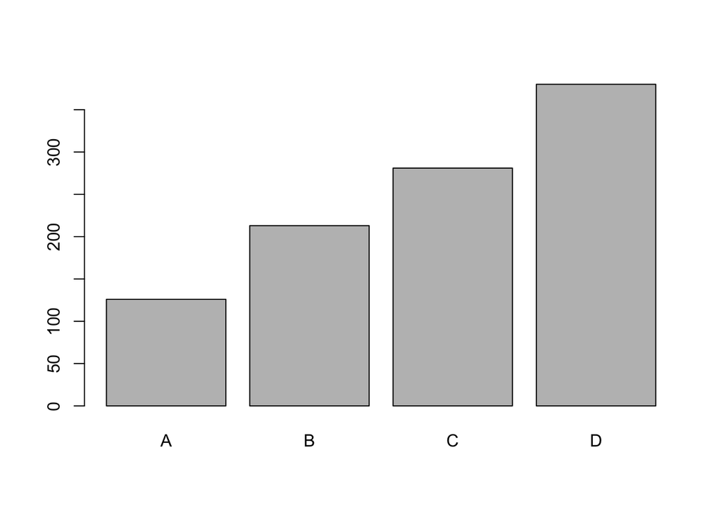

```r
barplot(table(data))
```

A, B, C, D 각각의 확률이 0.1, 0.2, 0.3, 0.4의 확률로 관찰됨을 확인할 수 있음.

**예제4**  
(동전 모의실험) 공평한 동전을 1000번 던져서 나오는 앞면의 수를 위의 `sample()`또는 `sample.int()` 함수를 사용하여 찾는다.

```r
table(sample(c("H","T"), 1000, replace = TRUE, prob=c(0.5, 0.5)))
```

```
##
##   H   T
## 513 487
```

## 이항분포

베르누이 시행을 n번 반복했을 때 k번 성공할 확률  
예) 추신수 선수가 오늘 경기에서 5번 타석에 들어와서 3번 안타를 칠 확률

### 이항분포의 성질

각각의 시행에서 성공확률이 $p$이고 실패확률이 $(1-p)$인 시행을 $n$번 독립적으로 시행할 때 성공의 횟수를 확률변수 $X$라고 하면 $X$의 분포를 이항분포라고 함.

$B(n,p)$로 표시하기도 함.

$X$가 이항분포인 경우 확률밀도함수

$$Pr[X=x]=\begin{pmatrix} n \\ x
\end{pmatrix} \quad p^x(1-p)^{n-x} \quad \quad x =
0,1,2,3,...,n$$

성공할 확률 $p$가 0이나 1에 가깝지 않고 $n$이 충분히 크면 이항분포는 정규분포에 가까워진다. 성공할 확률 $p$가 1/2에 가까우면 종모양이 된다.

### 이항분포 난수발생과 확률계산

이항분포의 확률값(`dbinom()`), 누적확률값(`pbinom()`), 분위수(`qbinom()`), 난수(`rbinom()`)을 구하기 위한 함수

**관련함수의 매개변수**  
- x, q: 확률밀도함수값을 얻을 x벡터, 누적확률을 얻을 분위수 q벡터  
- p: 분위수를 얻을 확률값의 벡터  
- n: 발생할 난수의 개수  
- lower.tail: 논리값을 설정하며 TRUE이면 확률은 $P[X \leq x]$의 값으로 그렇지 않으면 $P[X \gt x]$을 계산  
- size: 이항분포 $B(n,p)$에서 $n$값을 설정  
- prob: 이항분포 $B(n,p)$에서 $p$값을 설정

### 난수발생과 확률계산 함수 이름의 규칙

- R은 다양한 분포에 대해서 난수발생, 확률밀도함수값, 누적확률함수값, 분위수 계산을 할 수 있는 함수를 제공
- 함수가 가진 규칙
  1. r ~ : 분포의 이름이 ~인 분포에서 난수를 발생하는 함수, r을 접두어로 사용
  2. d ~ : 분포의 이름이 ~인 분포에서 확률밀도함수값을 발생하는 함수, d를 접두어로 사용
  3. p ~ : 분포의 이름이 ~인 분포에서 누적확률함수 $F(x) = Pr[X \leq x]$를 계산, p를 접두어로 사용
  4. q ~ : 분포의 이름이 ~인 분포에서 분위수를 계산, q를 접두어로 사용
- 이항분포의 경우 분포 이름으로 binom을 사용하고 각각 접두어에 r, d, p, q를 사용하였음을 알 수 있음.

### 이항분포 난수 발생과 확률계산 - 예제

X가 이항분포 $B(10, 0.2)$ (= 10번 시도하면 0.2번 성공하는 일) 경우 확률밀도함수 값은 아래와 같다.

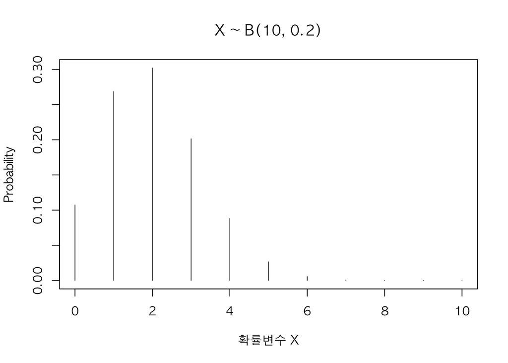

```r
y <- dbinom(0:10, 10, 0.2)
par(family = "AppleGothic")
plot(0:10, y, type = 'h', col = 'gray20', ylab = "Probability", xlab="확률변수 X",
     main="X ~ B(10, 0.2)")
```

예제1. 10번 시도하여 2번 성공할 확률

```r
dbinom(2, 10, 0.2) #B(10, 0.2), Pr[X = 2]
```

```
## [1] 0.3019899
```

예제2. 10번 시도하여 2번 성공할 확률의 누적확률 (0번, 1번, 2번이 될 확률의 누적)

```r
pbinom(2, 10, 0.2) #B(10, 0.2), Pr[X =< 2]
```

```
## [1] 0.6777995
```

위 `pbinom(2, 10, 0.2)`결과는 아래와 같은 의미임

```r
dbinom(0, 10, 0.2) + dbinom(1, 10, 0.2) + dbinom(2, 10, 0.2)
```

```
## [1] 0.6777995
```

예제3. 10번 시도하여 2번 초과하여 성공할 확률 (3번 ~ 10번)

```r
1-pbinom(2, 10, 0.2) #B(10, 0.2), Pr[X > 2]
```

```
## [1] 0.3222005
```

lower.tail 옵션을 FLASE로 설정하여 동일한 효과를 얻을 수 있음.

```r
pbinom(2, 10, 0.2, lower.tail = FALSE)
```

```
## [1] 0.3222005
```

예제4. 10번 시도하여 성공할 누적확률이 0.5가 되는 확률변수 (이산확률변수이기 때문에 누적확률이 0.5보다 크면서 가장 가까운 확률변수를 반환)

```r
qbinom(0.5, 10, 0.2)
```

```
## [1] 2
```

예제5. (동전모의실험) 이항분포는 성공확률이 $p$인 실험을 독립적으로 $n$번 시행할 때 성공의 횟수에 대한 분포이므로 앞면의 갯수는 이항분포 $B(1000, 0.5)$를 따른다. 1000번의 동전던지기에서 앞면의 갯수를 5회에 걸쳐 모의실험해보자.

```r
rbinom(1, 1000, 0.5)
```

```
## [1] 511
```

```r
rbinom(1, 1000, 0.5)
```

```
## [1] 499
```

```r
rbinom(1, 1000, 0.5)
```

```
## [1] 482
```

```r
rbinom(1, 1000, 0.5)
```

```
## [1] 478
```

```r
rbinom(1, 1000, 0.5)
```

```
## [1] 493
```

예제6. (주사위 던지기) 주사위를 던지면 1이 나올 확률이 1/6이다. 주사위를 다섯번 던질 때 1의 눈금이 나올 횟수를 확률변수 $X$라고 하면 $X$의 분포는 $B(5, 1/6)$이며 $X$의 기댓값과 분산은 각각 $E[X]=np=5/6=0.8333, \quad Var(X)=npq=25/36=0.6944$이다.  
주사위를 다섯번 던지는 실험을 100번 반복할 때 1의 눈금이 나온 횟수의 평균과 분산이 계산값과 얼마나 가까운지 모의실험을 해보자.

```r
binom.par <- function(nrep=100, n=5, p=1/6) {
  x <- rbinom(nrep, n, p) #B(n,p)에서 nrep개의 난수 생성
  meanx <- mean(x) #생성된 난수들의 평균
  varx <- var(x) #난수의 분산
  list(meanx = meanx, varx = varx)
}

binom.par() #결과는 random하게 바뀜
```

```
## $meanx
## [1] 0.82
##
## $varx
## [1] 0.6541414
```

## 초기하분포

### 초기하분포의 성질

초기하분포(hypergeometric distribution)은 m개의 빨간공과 n개의 흰공이 들어가 있는 주머니에서 k개를 비복원으로 뽑을 때 빨간공의 개수의 분포를 뜻한다.

`~hyper()`를 사용하여 구할 수 있다.

### 난수발생과 확률계산

로또의 경우 6개의 당첨번호(빨간공)와 나머지 39개의 비당첨번호(흰공)로 45개의 공이 들어가 있는 주머니에서 6개를 뽑는 경우로 m=6, n=39, k=6인 경우임.

`dhyper()`함수로 확률 계산하기 $\rightarrow$ 로또에서 0~6개의 번호를 맞출 확률을 출력해 줌

```r
dhyper(0:6, 6, 39, 6)
```

```
## [1] 4.005646e-01 4.241273e-01 1.514740e-01 2.244060e-02 1.364631e-03
## [6] 2.872907e-05 1.227738e-07
```

6개를 다 맞출 확률은

```r
dhyper(6, 6, 39, 6)
```

```
## [1] 1.227738e-07
```

예제2. 로또에서 3개 이상의 번호를 맞출 확률을 계산해 보자

```r
1-phyper(2, 6, 39, 6)
```

```
## [1] 0.02383408
```

## 동일한 난수 생성하기

### set.seed 함수

한 번 발생한 난수를 그대로 발생하고자 하는 경우 동일한 난수를 얻게 설정하는 함수

**중요!!!** 이 함수는 자주 사용됨.

`set.seed()` 함수를 사용하고 사용자가 임의로 정한 값을 입력하면 됨.

### 동일한 난수 생성: `set.seed()`함수

set.seed 설정 전

```r
rbinom(10, 100, 0.5)
```

```
##  [1] 46 49 54 55 49 50 51 40 42 48
```

```r
rbinom(10, 100, 0.5)
```

```
##  [1] 48 50 53 51 47 53 47 49 53 48
```

```r
rbinom(10, 100, 0.5)
```

```
##  [1] 57 54 42 48 56 51 44 51 48 48
```

난수를 생성할 때마다 다른 값이 생성됨.

set.seed 설정 후

```r
set.seed(1234)
rbinom(10, 100, 0.5)
```

```
##  [1] 47 40 48 47 48 53 52 53 53 47
```

```r
set.seed(1234)
rbinom(10, 100, 0.5)
```

```
##  [1] 47 40 48 47 48 53 52 53 53 47
```

```r
set.seed(1234)
rbinom(10, 100, 0.5)
```

```
##  [1] 47 40 48 47 48 53 52 53 53 47
```

`set.seed()`값을 동일하게 주면 동일한 난수가 생성됨.